# Restaurant Data Analysis

Mark Kwabena Awuku

2025-11-02

# Part 1: Data Loading and Cleaning

### 1.2 Data Attributes

- `rating`: The primary target variable for prediction/analysis.
- `userRatingCount`: Critical feature indicating popularity/credibility.
- `primaryType`: The category of restaurant (e.g., Mexican, Thai). Essential for segmentation.
- `businessStatus`: Crucial to filter out closed/temporarily closed restaurants if analyzing operational performance.
- `priceStartUSD`, `priceEndUSD`: Important for price segmentation, but they require cleaning.
- **Service & Amenity Booleans**: (`takeout`, `delivery`, `servesDinner`, `servesWine`, `servesCocktails`, `wheelchairAccessible`… etc.): These may be valuable for feature engineering and market segmentation.

```r
# Load the dataset CSV
restuarant_data = read_csv("data/combined_restaurants.csv")
cat("---Number of Obervations and Attributes---\n")
```

```
## ---Number of Obervations and Attributes---
```

```r
cat("Number of Observations (# of rows): " , nrow(restuarant_data), "\n")
```

```
## Number of Observations (# of rows):  10018
```

```r
cat("Number of Attributes (# of columns): " , ncol(restuarant_data), "\n")
```

```
## Number of Attributes (# of columns):  34
```

```r
# The 'glimpse' function provides a transposed view of the data, which is great for viewing types
#glimpse(restuarant_data)

# Summary provides min, max, median, mean, and quartiles for numeric columns
summary(restuarant_data)
```

```
##       id                name               rating      userRatingCount
##  Length:10018       Length:10018       Min.   :1.000   Min.   :    1.0
##  Class :character   Class :character   1st Qu.:3.900   1st Qu.:  101.0
##  Mode  :character   Mode  :character   Median :4.300   Median :  323.0
##                                        Mean   :4.171   Mean   :  641.3
##                                        3rd Qu.:4.600   3rd Qu.:  760.0
##                                        Max.   :5.000   Max.   :23596.0
##                                        NA's   :540     NA's   :540
##  formattedAddress      latitude       longitude         phone
##  Length:10018       Min.   :41.64   Min.   :-87.94   Length:10018
##  Class :character   1st Qu.:41.81   1st Qu.:-87.77   Class :character
##  Mode  :character   Median :41.89   Median :-87.70   Mode  :character
##                     Mean   :41.87   Mean   :-87.72
##                     3rd Qu.:41.94   3rd Qu.:-87.65
##                     Max.   :42.02   Max.   :-87.52
##
##  businessStatus     primaryType         takeout         delivery
##  Length:10018       Length:10018       Mode :logical   Mode :logical
##  Class :character   Class :character   FALSE:119       FALSE:1252
##  Mode  :character   Mode  :character   TRUE :9093      TRUE :7257
##                                        NA's :806       NA's :1509
##
##
##
##    dineIn        curbsidePickup  reservable      servesLunch
##  Mode :logical   Mode :logical   Mode :logical   Mode :logical
##  FALSE:300       FALSE:2220      FALSE:3191      FALSE:193
##  TRUE :8279      TRUE :2343      TRUE :2959      TRUE :7912
##  NA's :1439      NA's :5455      NA's :3868      NA's :1913
##
##
##
##  servesDinner    servesBeer      servesWine      liveMusic
##  Mode :logical   Mode :logical   Mode :logical   Mode :logical
##  FALSE:316       FALSE:4071      FALSE:4199      FALSE:6618
##  TRUE :7561      TRUE :2878      TRUE :2524      TRUE :560
##  NA's :2141      NA's :3069      NA's :3295      NA's :2840
##
##
##
```

[output cut: 25 more lines]

```
##  Mode :logical               Min.   :  1.00   Min.   : 10.00
##  FALSE:375                   1st Qu.: 10.00   1st Qu.: 20.00
##  TRUE :5114                  Median : 10.00   Median : 20.00
##  NA's :4529                  Mean   : 13.45   Mean   : 23.87
##                              3rd Qu.: 10.00   3rd Qu.: 20.00
##                              Max.   :100.00   Max.   :100.00
##                              NA's   :2550     NA's   :2638
##  googleMapsUri
##  Length:10018
##  Class :character
##  Mode  :character
##
##
##
##
```

```r
# View all column names
colnames(restuarant_data)
```

```
##  [1] "id"                           "name"
##  [3] "rating"                       "userRatingCount"
##  [5] "formattedAddress"             "latitude"
##  [7] "longitude"                    "phone"
##  [9] "businessStatus"               "primaryType"
## [11] "takeout"                      "delivery"
## [13] "dineIn"                       "curbsidePickup"
## [15] "reservable"                   "servesLunch"
## [17] "servesDinner"                 "servesBeer"
## [19] "servesWine"                   "liveMusic"
## [21] "servesCocktails"              "goodForChildren"
## [23] "acceptsCreditCards"           "acceptsDebitCards"
## [25] "acceptsCashOnly"              "acceptsNfc"
## [27] "freeParkingLot"               "freeStreetParking"
## [29] "wheelchairAccessibleEntrance" "wheelchairAccessibleRestroom"
## [31] "wheelchairAccessibleSeating"  "priceStartUSD"
## [33] "priceEndUSD"                  "googleMapsUri"
```

```r
# View data in highly formatted output
#datatable(restuarant_data)
```

### 1.3 Attributes to Drop

- `id`, `googleMapsUri`: Unique identifier (non-analytical values).
- `formattedAddress`, `phone`: Not useful for statistical modeling without extensive NLP or geo-processing
- `name`: Too high cardinality/unique.
- `lattitude`, `longitude`: High dimensional, rarely used in simple models).

```r
# drop attributes
# tidyverse uses `select` with negative sign (-)
clean_data = restuarant_data %>%
  select(-id, -googleMapsUri, -formattedAddress, -phone, -name, -latitude, -longitude)
```

### 1.4 Clean Rows With Missing values

Will focus on:

```r
# Handle missing values in critical columns
clean_data = clean_data %>%
  filter(!is.na(rating) & !is.na(userRatingCount))

# Clean boolean columns
bool_cols = c("takeout", "delivery", "dineIn", "curbsidePickup", "reservable",
                 "servesLunch", "servesDinner", "servesBeer", "servesWine", "liveMusic",
                 "servesCocktails", "goodForChildren", "acceptsCreditCards",
                 "acceptsDebitCards", "acceptsCashOnly", "acceptsNfc", "freeParkingLot",
                 "freeStreetParking", "wheelchairAccessibleEntrance",
                 "wheelchairAccessibleRestroom", "wheelchairAccessibleSeating")

# Ensure columns are logical (TRUE/FALSE) and impute missing as FALSE
clean_data = clean_data %>%
  mutate(across(all_of(bool_cols),
                ~ifelse(is.na(.) | . == "False", FALSE, TRUE)))

# Clean price columns
clean_data = clean_data %>%
  mutate(priceStartUSD = as.numeric(priceStartUSD),
         priceEndUSD = as.numeric(priceEndUSD)) %>%
  filter(!is.na(priceStartUSD) & !is.na(priceEndUSD))


# Final check of dimensions and missing values
cat("\n--- Final Cleaned Data Dimensions (R) ---\n")
```

```
##
## --- Final Cleaned Data Dimensions (R) ---
```

```r
cat("Observations (Rows):", nrow(clean_data), "\n")
```

```
## Observations (Rows): 7378
```

```r
cat("Attributes (Columns):", ncol(clean_data), "\n")
```

```
## Attributes (Columns): 27
```

```r
cat("\n--- Missing Values Check After Final Clean (R) ---\n")
```

```
##
## --- Missing Values Check After Final Clean (R) ---
```

```r
sapply(clean_data, function(x) sum(is.na(x)))
```

```
##                       rating              userRatingCount
##                            0                            0
##               businessStatus                  primaryType
##                            0                            0
##                      takeout                     delivery
##                            0                            0
##                       dineIn               curbsidePickup
##                            0                            0
##                   reservable                  servesLunch
##                            0                            0
##                 servesDinner                   servesBeer
##                            0                            0
##                   servesWine                    liveMusic
##                            0                            0
##              servesCocktails              goodForChildren
##                            0                            0
##           acceptsCreditCards            acceptsDebitCards
##                            0                            0
##              acceptsCashOnly                   acceptsNfc
##                            0                            0
##               freeParkingLot            freeStreetParking
##                            0                            0
## wheelchairAccessibleEntrance wheelchairAccessibleRestroom
##                            0                            0
##  wheelchairAccessibleSeating                priceStartUSD
##                            0                            0
##                  priceEndUSD
##                            0
```

```r
# Save Cleaned Data
output_file = "data/cleaned_restaurant.csv"
write_csv(clean_data, output_file)
```

# Part 2: Exploratory Data Analysis (EDA)

```r
summary(clean_data)
```

```
##      rating      userRatingCount   businessStatus     primaryType
##  Min.   :1.200   Min.   :    2.0   Length:7378        Length:7378
##  1st Qu.:3.900   1st Qu.:  159.2   Class :character   Class :character
##  Median :4.300   Median :  384.0   Mode  :character   Mode  :character
##  Mean   :4.195   Mean   :  681.8
##  3rd Qu.:4.500   3rd Qu.:  808.0
##  Max.   :5.000   Max.   :23596.0
##   takeout         delivery         dineIn        curbsidePickup
##  Mode :logical   Mode :logical   Mode :logical   Mode :logical
##  FALSE:141       FALSE:541       FALSE:500       FALSE:3709
##  TRUE :7237      TRUE :6837      TRUE :6878      TRUE :3669
##
##
##
##  reservable      servesLunch     servesDinner    servesBeer
##  Mode :logical   Mode :logical   Mode :logical   Mode :logical
##  FALSE:2099      FALSE:643       FALSE:838       FALSE:1427
##  TRUE :5279      TRUE :6735      TRUE :6540      TRUE :5951
##
##
##
##  servesWine      liveMusic       servesCocktails goodForChildren
##  Mode :logical   Mode :logical   Mode :logical   Mode :logical
##  FALSE:1592      FALSE:1421      FALSE:1941      FALSE:1309
##  TRUE :5786      TRUE :5957      TRUE :5437      TRUE :6069
##
##
##
##  acceptsCreditCards acceptsDebitCards acceptsCashOnly acceptsNfc
##  Mode :logical      Mode :logical     Mode :logical   Mode :logical
##  FALSE:703          FALSE:453         FALSE:235       FALSE:1254
##  TRUE :6675         TRUE :6925        TRUE :7143      TRUE :6124
##
##
##
##  freeParkingLot  freeStreetParking wheelchairAccessibleEntrance
##  Mode :logical   Mode :logical     Mode :logical
##  FALSE:3558      FALSE:3138        FALSE:1749
##  TRUE :3820      TRUE :4240        TRUE :5629
##
##
##
##  wheelchairAccessibleRestroom wheelchairAccessibleSeating priceStartUSD
##  Mode :logical                Mode :logical               Min.   : 1.00
##  FALSE:3040                   FALSE:2697                  1st Qu.:10.00
##  TRUE :4338                   TRUE :4681                  Median :10.00
##                                                           Mean   :12.42
##                                                           3rd Qu.:10.00
##                                                           Max.   :50.00
##   priceEndUSD
##  Min.   : 10.00
##  1st Qu.: 20.00
##  Median : 20.00
##  Mean   : 23.87
##  3rd Qu.: 20.00
##  Max.   :100.00
```

### 2.1 Histogram Distribution of Ratings

Histogram helps to visualize the central tendancy and spread of restaurant ratings

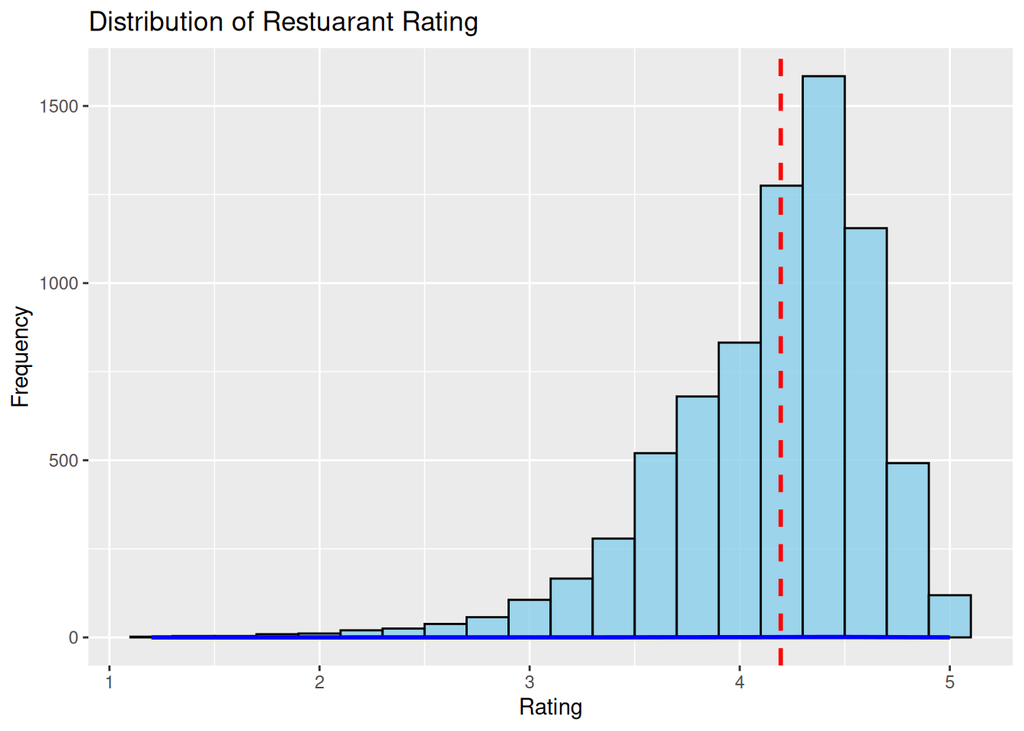

```r
ggplot(clean_data, aes(x=rating)) +
  geom_histogram(binwidth = 0.2, fill='skyblue', color='black', alpha=0.8) +
  # Add density line (equivalent to KDE)
  geom_density(color = "blue", linewidth = 1) +
  # Add vertical line for the mean
  geom_vline(aes(xintercept = mean(rating)),
             color = "red", linetype = "dashed", linewidth = 1,
             show.legend = TRUE) +
  labs(
    title = 'Distribution of Restuarant Rating',
    x = 'Rating',
    y = 'Frequency'
  )
```

### 2.2 Boxplot: Rating Distribution by Business Type

Boxplot will help visualize how quantitative variable (`rating`) is distributed across different categories (`primaryType`)

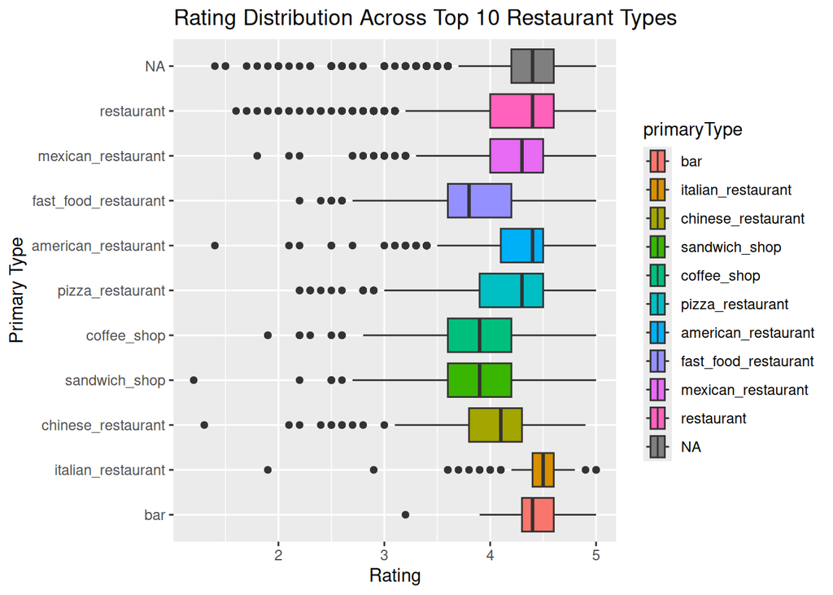

```r
# identity top 10 types
top_types = clean_data %>%
  count(primaryType, sort = TRUE) %>%
  slice_head(n=10) %>%
  pull(primaryType)

data_top_types = clean_data %>%
  # convert primaryType to a factor for proper ordering in the plot
  mutate(primaryType=factor(primaryType, levels = rev(top_types)))

# generate boxplot
ggplot(data_top_types, aes(x=rating, y=primaryType, fill=primaryType)) +
  geom_boxplot() +
  labs(
    title = 'Rating Distribution Across Top 10 Restaurant Types',
    x = 'Rating',
    y = 'Primary Type'
  )
```

# Part 3: Hypothesis Construction

We are testing whether the population mean of `rating` are equal across the different categories of restaurant `primaryType` (or among the top 5 types).

- **Null hypothesis ($H_0$)**: The true mean of restaurant rating is the same for all primary restaurant types.

$$H_0: {\mu}_{type1} = {\mu}_{type2} =
{\mu}_{type2} = ... = {\mu}_{type5}$$

- **Alternative hypothesis ($H_1$)**: At least one primary restaurant type has a true mean rating that is significantly different from the others.

$$H_1: {\mu}_{type1} \ne {\mu}_{type2}
\ne ... \ne {\mu}_{type5}$$

- **Test Method**: One way Analysis of Variance (ANOVA)
- **Significance level ($\alpha$)**: 0.05

```r
# filter for top 5 primaryTypes
top_5_primeTypes = clean_data %>%
  count(primaryType, sort = TRUE) %>%
  slice_head(n=5) %>%
  pull(primaryType)

top_5_anova_data = clean_data %>%
  filter(primaryType %in% top_5_primeTypes) %>%
  mutate(primaryType = factor(primaryType)) # Ensure the type is a factor

# ANOVA for top 5 primaryTypes
anova_5_results = aov(rating ~ primaryType, data=top_5_anova_data)

# view summary of top 5 primaryTypes
summary(anova_5_results)
```

```
##               Df Sum Sq Mean Sq F value Pr(>F)
## primaryType    4   82.5  20.620   89.21 <2e-16 ***
## Residuals   4200  970.8   0.231
## ---
## Signif. codes:  0 '***' 0.001 '**' 0.01 '*' 0.05 '.' 0.1 ' ' 1
```

```r
# ANOVA for all primaryTypes
anova_results = aov(rating ~ primaryType, data=clean_data)

# View summary
summary(anova_results)
```

```
##               Df Sum Sq Mean Sq F value Pr(>F)
## primaryType   55    294   5.345   25.43 <2e-16 ***
## Residuals   7322   1539   0.210
## ---
## Signif. codes:  0 '***' 0.001 '**' 0.01 '*' 0.05 '.' 0.1 ' ' 1
```

### Conclusion

> - P-value Analysis: The calculated p-value is extremely small, for less than the significance level of $\alpha=0.05$
> - Decision: Since the p-value is less thatn $\alpha$, we **reject the null hypotheis**.
> - We have statistical evidence tp conclude that there is a difference in the mean customer rating among the top five primary restuarant types (including all types). In other words, the type of restaurant is a significant factor in predicting customer rating.

# Part 4: Linear Regression Model with Subset Selection

```r
library(MLmetrics)
library(MASS) # Run stepwise regression, MASS package required
```

### 4.1: Split data set into 80:20 train and test data with name `RestaurantTraining` and `RestaurantTest` respectively

```r
# Setting the seed fixes the randomness in the sample() function
set.seed(42)

# Ensure primaryType is a factor
data_to_split = clean_data %>%
  mutate(primaryType = as.factor(primaryType))

i = sample(2, nrow(data_to_split), replace = TRUE, prob = c(0.8, 0.2))

RestaurantTraining = data_to_split[i==1, ] # 80% Training sample
RestaurantTest = data_to_split[i==2, ] # 20% Testing sample

# Check new dimensions
cat("Training set size:", nrow(RestaurantTraining), "\n")
```

```
## Training set size: 5881
```

```r
cat("Testing set size:", nrow(RestaurantTest), "\n")
```

```
## Testing set size: 1497
```

```r
colnames(RestaurantTraining)
```

```
##  [1] "rating"                       "userRatingCount"
##  [3] "businessStatus"               "primaryType"
##  [5] "takeout"                      "delivery"
##  [7] "dineIn"                       "curbsidePickup"
##  [9] "reservable"                   "servesLunch"
## [11] "servesDinner"                 "servesBeer"
## [13] "servesWine"                   "liveMusic"
## [15] "servesCocktails"              "goodForChildren"
## [17] "acceptsCreditCards"           "acceptsDebitCards"
## [19] "acceptsCashOnly"              "acceptsNfc"
## [21] "freeParkingLot"               "freeStreetParking"
## [23] "wheelchairAccessibleEntrance" "wheelchairAccessibleRestroom"
## [25] "wheelchairAccessibleSeating"  "priceStartUSD"
## [27] "priceEndUSD"
```

```r
colnames(RestaurantTest)
```

```
##  [1] "rating"                       "userRatingCount"
##  [3] "businessStatus"               "primaryType"
##  [5] "takeout"                      "delivery"
##  [7] "dineIn"                       "curbsidePickup"
##  [9] "reservable"                   "servesLunch"
## [11] "servesDinner"                 "servesBeer"
## [13] "servesWine"                   "liveMusic"
## [15] "servesCocktails"              "goodForChildren"
## [17] "acceptsCreditCards"           "acceptsDebitCards"
## [19] "acceptsCashOnly"              "acceptsNfc"
## [21] "freeParkingLot"               "freeStreetParking"
## [23] "wheelchairAccessibleEntrance" "wheelchairAccessibleRestroom"
## [25] "wheelchairAccessibleSeating"  "priceStartUSD"
## [27] "priceEndUSD"
```

### 4.2: Multiple Regression Model

```r
# construct multiple linear regression model
mr_model = lm(rating ~ . , data = RestaurantTraining )

# display summary of the model
summary(mr_model)
```

```
##
## Call:
## lm(formula = rating ~ ., data = RestaurantTraining)
##
## Residuals:
##      Min       1Q   Median       3Q      Max
## -3.05526 -0.19807  0.05602  0.27360  1.17887
##
## Coefficients:
##                                        Estimate Std. Error t value Pr(>|t|)
## (Intercept)                           4.503e+00  2.618e-01  17.202  < 2e-16 ***
## userRatingCount                       2.869e-05  5.807e-06   4.941 8.01e-07 ***
## businessStatusCLOSED_TEMPORARILY      2.657e-01  1.323e-01   2.008 0.044696 *
## businessStatusOPERATIONAL             2.115e-01  1.283e-01   1.649 0.099279 .
## primaryTypeafghani_restaurant        -3.970e-01  4.950e-01  -0.802 0.422613
## primaryTypeafrican_restaurant        -3.677e-01  2.715e-01  -1.354 0.175799
## primaryTypeamerican_restaurant       -4.849e-01  2.232e-01  -2.172 0.029862 *
## primaryTypeasian_restaurant          -4.255e-01  2.304e-01  -1.847 0.064831 .
## primaryTypebagel_shop                -4.932e-01  2.589e-01  -1.905 0.056850 .
## primaryTypebakery                    -2.431e-01  2.390e-01  -1.017 0.309149
## primaryTypebar                       -4.197e-01  2.250e-01  -1.866 0.062150 .
## primaryTypebar_and_grill             -3.891e-01  2.263e-01  -1.719 0.085600 .
## primaryTypebarbecue_restaurant       -6.695e-01  2.298e-01  -2.913 0.003589 **
## primaryTypebrazilian_restaurant      -5.298e-01  3.197e-01  -1.657 0.097603 .
## primaryTypebreakfast_restaurant      -4.062e-01  2.252e-01  -1.804 0.071244 .
## primaryTypebrunch_restaurant         -3.975e-01  2.475e-01  -1.606 0.108358
## primaryTypebuffet_restaurant         -8.014e-01  2.617e-01  -3.063 0.002203 **
## primaryTypecafe                      -4.869e-01  2.277e-01  -2.138 0.032544 *
## primaryTypecafeteria                  1.336e-01  4.941e-01   0.270 0.786833
## primaryTypechinese_restaurant        -7.052e-01  2.239e-01  -3.150 0.001642 **
## primaryTypecoffee_shop               -7.814e-01  2.237e-01  -3.493 0.000481 ***
## primaryTypedeli                      -7.371e-02  2.461e-01  -0.299 0.764578
## primaryTypediner                     -4.041e-01  2.372e-01  -1.703 0.088538 .
## primaryTypedonut_shop                -3.417e-01  2.539e-01  -1.346 0.178355
## primaryTypefast_food_restaurant      -8.672e-01  2.248e-01  -3.857 0.000116 ***
## primaryTypefine_dining_restaurant    -4.526e-01  3.389e-01  -1.335 0.181835
## primaryTypefood_court                -1.539e-01  3.832e-01  -0.402 0.688053
## primaryTypefood_store                -2.180e-01  2.860e-01  -0.762 0.446066
## primaryTypefrench_restaurant         -3.910e-01  2.637e-01  -1.483 0.138181
## primaryTypegreek_restaurant          -3.989e-01  2.430e-01  -1.642 0.100687
```

[output cut: 42 more lines]

```
## acceptsCashOnlyTRUE                  -6.425e-02  5.229e-02  -1.229 0.219282
## acceptsNfcTRUE                       -6.281e-02  1.896e-02  -3.312 0.000933 ***
## freeParkingLotTRUE                   -9.664e-02  1.372e-02  -7.046 2.06e-12 ***
## freeStreetParkingTRUE                 1.052e-01  1.346e-02   7.819 6.29e-15 ***
## wheelchairAccessibleEntranceTRUE     -1.081e-01  1.734e-02  -6.236 4.80e-10 ***
## wheelchairAccessibleRestroomTRUE     -2.168e-02  1.615e-02  -1.342 0.179574
## wheelchairAccessibleSeatingTRUE       3.248e-02  1.700e-02   1.911 0.056012 .
## priceStartUSD                         5.135e-03  2.944e-03   1.745 0.081113 .
## priceEndUSD                           5.638e-04  1.651e-03   0.341 0.732771
## ---
## Signif. codes:  0 '***' 0.001 '**' 0.01 '*' 0.05 '.' 0.1 ' ' 1
##
## Residual standard error: 0.4406 on 5800 degrees of freedom
## Multiple R-squared:  0.2246, Adjusted R-squared:  0.2139
## F-statistic:    21 on 80 and 5800 DF,  p-value: < 2.2e-16
```

```r
# Extract the factor levels used by the model
mr_levels = mr_model$xlevels$primaryType

# Filter the testset to only include levels present in the training set
RestaurantTest$primaryType = factor(RestaurantTest$primaryType, levels = mr_levels)

# Predicting rating
ypred = predict(object=mr_model, newdata = RestaurantTest)

# Create a data frame with true and predicted values
mr_df <- data.frame(
  y_true = RestaurantTest$rating,
  y_pred = ypred
) %>% na.omit() # Remove rows with NA values in either column

# mean absolute error of predicted rating, and Actual rating
MAE(y_pred = mr_df$y_pred, y_true = RestaurantTest$rating)
```

```
## [1] 0.3558855
```

```r
# mean square error of predicted rating, and Actual rating
MSE(y_pred = mr_df$y_pred, y_true = RestaurantTest$rating)
```

```
## [1] 0.2302726
```

### 4.3: Subset Selection Linear Regression Model

```r
# create a null model / intercept only mode
null_model = lm(rating ~ 1, data = RestaurantTraining)

# create a full model
full_model = lm(rating~. , data = RestaurantTraining)

# perform step-wise selection using stepAIC()
step_forward = stepAIC(null_model, direction='forward', scope=formula(full_model))
```

```
## Start:  AIC=-8222.59
## rating ~ 1
##
##                                Df Sum of Sq    RSS     AIC
## + primaryType                  54   239.869 1212.5 -9176.1
## + priceStartUSD                 1    82.035 1370.4 -8562.5
## + priceEndUSD                   1    63.585 1388.8 -8483.9
## + freeParkingLot                1    37.802 1414.6 -8375.7
## + acceptsNfc                    1    17.088 1435.3 -8290.2
## + wheelchairAccessibleEntrance  1    14.015 1438.4 -8277.6
## + servesDinner                  1    13.815 1438.6 -8276.8
## + servesLunch                   1    13.751 1438.7 -8276.5
## + acceptsDebitCards             1    10.986 1441.4 -8265.2
## + goodForChildren               1     8.365 1444.0 -8254.6
## + liveMusic                     1     7.711 1444.7 -8251.9
## + servesCocktails               1     6.996 1445.4 -8249.0
## + acceptsCashOnly               1     6.692 1445.7 -8247.7
## + wheelchairAccessibleSeating   1     6.196 1446.2 -8245.7
## + userRatingCount               1     5.222 1447.2 -8241.8
## + reservable                    1     3.869 1448.5 -8236.3
## + dineIn                        1     2.281 1450.1 -8229.8
## + acceptsCreditCards            1     1.946 1450.5 -8228.5
## + curbsidePickup                1     1.540 1450.9 -8226.8
## + servesWine                    1     1.489 1450.9 -8226.6
## + takeout                       1     1.306 1451.1 -8225.9
## + servesBeer                    1     1.101 1451.3 -8225.0
## + businessStatus                2     1.028 1451.4 -8222.8
## <none>                                      1452.4 -8222.6
## + freeStreetParking             1     0.287 1452.1 -8221.7
## + delivery                      1     0.238 1452.2 -8221.6
## + wheelchairAccessibleRestroom  1     0.141 1452.3 -8221.2
##
## Step:  AIC=-9176.14
## rating ~ primaryType
##
##                                Df Sum of Sq    RSS     AIC
## + priceStartUSD                 1   14.8207 1197.7 -9246.5
## + priceEndUSD                   1   13.3741 1199.2 -9239.4
## + wheelchairAccessibleEntrance  1    8.4046 1204.1 -9215.0
## + freeParkingLot                1    7.7221 1204.8 -9211.7
```

[output cut: 434 more lines]

```
## rating ~ primaryType + priceStartUSD + wheelchairAccessibleEntrance +
##     goodForChildren + servesDinner + freeStreetParking + freeParkingLot +
##     curbsidePickup + userRatingCount + acceptsNfc + delivery +
##     servesWine + servesCocktails + acceptsDebitCards + acceptsCreditCards +
##     liveMusic + businessStatus + dineIn + wheelchairAccessibleSeating
##
##                                Df Sum of Sq    RSS     AIC
## <none>                                      1127.3 -9567.0
## + servesBeer                    1   0.34246 1126.9 -9566.8
## + wheelchairAccessibleRestroom  1   0.30267 1127.0 -9566.6
## + acceptsCashOnly               1   0.26372 1127.0 -9566.4
## + servesLunch                   1   0.05401 1127.2 -9565.3
## + priceEndUSD                   1   0.02237 1127.2 -9565.1
## + takeout                       1   0.01557 1127.3 -9565.1
## + reservable                    1   0.01156 1127.3 -9565.0
```

```r
# view results of forward stepwise regression
step_forward$anova
```

```
## Stepwise Model Path
## Analysis of Deviance Table
##
## Initial Model:
## rating ~ 1
##
## Final Model:
## rating ~ primaryType + priceStartUSD + wheelchairAccessibleEntrance +
##     goodForChildren + servesDinner + freeStreetParking + freeParkingLot +
##     curbsidePickup + userRatingCount + acceptsNfc + delivery +
##     servesWine + servesCocktails + acceptsDebitCards + acceptsCreditCards +
##     liveMusic + businessStatus + dineIn + wheelchairAccessibleSeating
##
##
##                              Step Df    Deviance Resid. Df Resid. Dev       AIC
## 1                                                     5880   1452.412 -8222.585
## 2                   + primaryType 54 239.8691581      5826   1212.543 -9176.141
## 3                 + priceStartUSD  1  14.8206567      5825   1197.722 -9246.466
## 4  + wheelchairAccessibleEntrance  1  10.6653093      5824   1187.057 -9297.069
## 5               + goodForChildren  1  10.6885878      5823   1176.368 -9348.263
## 6                  + servesDinner  1   8.4431698      5822   1167.925 -9388.625
## 7             + freeStreetParking  1   6.3441085      5821   1161.581 -9418.657
## 8                + freeParkingLot  1   8.4276474      5820   1153.153 -9459.481
## 9                + curbsidePickup  1   5.7256404      5819   1147.428 -9486.755
## 10              + userRatingCount  1   4.1396511      5818   1143.288 -9506.010
## 11                   + acceptsNfc  1   3.9168846      5817   1139.371 -9524.193
## 12                     + delivery  1   2.8703370      5816   1136.501 -9537.027
## 13                   + servesWine  1   1.8883618      5815   1134.612 -9544.807
## 14              + servesCocktails  1   2.3196948      5814   1132.293 -9554.843
## 15            + acceptsDebitCards  1   1.6732152      5813   1130.620 -9561.540
## 16           + acceptsCreditCards  1   0.8051994      5812   1129.814 -9563.730
## 17                    + liveMusic  1   0.6483925      5811   1129.166 -9565.106
## 18               + businessStatus  2   0.8890776      5809   1128.277 -9565.738
## 19                       + dineIn  1   0.5306825      5808   1127.746 -9566.505
## 20  + wheelchairAccessibleSeating  1   0.4744871      5807   1127.272 -9566.980
```

```r
# view final model
summary(step_forward)
```

```
##
## Call:
## lm(formula = rating ~ primaryType + priceStartUSD + wheelchairAccessibleEntrance +
##     goodForChildren + servesDinner + freeStreetParking + freeParkingLot +
##     curbsidePickup + userRatingCount + acceptsNfc + delivery +
##     servesWine + servesCocktails + acceptsDebitCards + acceptsCreditCards +
##     liveMusic + businessStatus + dineIn + wheelchairAccessibleSeating,
##     data = RestaurantTraining)
##
## Residuals:
##      Min       1Q   Median       3Q      Max
## -3.02811 -0.19673  0.05493  0.27232  1.20426
##
## Coefficients:
##                                        Estimate Std. Error t value Pr(>|t|)
## (Intercept)                           4.504e+00  2.581e-01  17.455  < 2e-16 ***
## primaryTypeafghani_restaurant        -4.033e-01  4.947e-01  -0.815 0.415014
## primaryTypeafrican_restaurant        -3.822e-01  2.713e-01  -1.409 0.158912
## primaryTypeamerican_restaurant       -4.879e-01  2.230e-01  -2.188 0.028717 *
## primaryTypeasian_restaurant          -4.323e-01  2.302e-01  -1.878 0.060450 .
## primaryTypebagel_shop                -5.125e-01  2.586e-01  -1.982 0.047552 *
## primaryTypebakery                    -2.521e-01  2.388e-01  -1.056 0.291085
## primaryTypebar                       -4.302e-01  2.244e-01  -1.917 0.055268 .
## primaryTypebar_and_grill             -3.942e-01  2.261e-01  -1.744 0.081230 .
## primaryTypebarbecue_restaurant       -6.723e-01  2.296e-01  -2.929 0.003416 **
## primaryTypebrazilian_restaurant      -5.345e-01  3.193e-01  -1.674 0.094191 .
## primaryTypebreakfast_restaurant      -4.131e-01  2.249e-01  -1.837 0.066208 .
## primaryTypebrunch_restaurant         -4.085e-01  2.472e-01  -1.653 0.098461 .
## primaryTypebuffet_restaurant         -8.000e-01  2.615e-01  -3.059 0.002231 **
## primaryTypecafe                      -4.943e-01  2.274e-01  -2.174 0.029782 *
## primaryTypecafeteria                  1.205e-01  4.936e-01   0.244 0.807203
## primaryTypechinese_restaurant        -7.062e-01  2.236e-01  -3.158 0.001598 **
## primaryTypecoffee_shop               -7.840e-01  2.232e-01  -3.513 0.000447 ***
## primaryTypedeli                      -8.085e-02  2.460e-01  -0.329 0.742432
## primaryTypediner                     -4.036e-01  2.369e-01  -1.704 0.088515 .
## primaryTypedonut_shop                -3.481e-01  2.535e-01  -1.373 0.169802
## primaryTypefast_food_restaurant      -8.691e-01  2.244e-01  -3.872 0.000109 ***
## primaryTypefine_dining_restaurant    -4.589e-01  3.383e-01  -1.356 0.175032
## primaryTypefood_court                -1.712e-01  3.830e-01  -0.447 0.654866
## primaryTypefood_store                -2.203e-01  2.855e-01  -0.772 0.440272
```

[output cut: 40 more lines]

```
## servesWineTRUE                        9.880e-02  2.380e-02   4.151 3.35e-05 ***
## servesCocktailsTRUE                  -7.434e-02  2.409e-02  -3.086 0.002035 **
## acceptsDebitCardsTRUE                -1.227e-01  3.404e-02  -3.605 0.000315 ***
## acceptsCreditCardsTRUE                6.314e-02  2.665e-02   2.369 0.017845 *
## liveMusicTRUE                        -3.656e-02  2.162e-02  -1.691 0.090963 .
## businessStatusCLOSED_TEMPORARILY      2.626e-01  1.322e-01   1.987 0.046977 *
## businessStatusOPERATIONAL             2.111e-01  1.281e-01   1.648 0.099444 .
## dineInTRUE                            3.989e-02  2.542e-02   1.569 0.116596
## wheelchairAccessibleSeatingTRUE       2.469e-02  1.579e-02   1.563 0.118010
## ---
## Signif. codes:  0 '***' 0.001 '**' 0.01 '*' 0.05 '.' 0.1 ' ' 1
##
## Residual standard error: 0.4406 on 5807 degrees of freedom
## Multiple R-squared:  0.2239, Adjusted R-squared:  0.2141
## F-statistic: 22.94 on 73 and 5807 DF,  p-value: < 2.2e-16
```

- Use the `step_forward` model to predict `rating` in `RestaurantTest` and calculate `MAE` and `MSE`.

```r
# Extract the factor levels used by the model
model_levels = step_forward$xlevels$primaryType

# Filter the testset to only include levels present in the training set
RestaurantTest$primaryType = factor(RestaurantTest$primaryType, levels = model_levels)

# Predicting rating
ypred_forward = predict(object=step_forward, newdata = RestaurantTest)

# Create a data frame with true and predicted values
results_df <- data.frame(
  y_true = RestaurantTest$rating,
  y_pred = ypred_forward
) %>% na.omit() # Remove rows with NA values in either column

# mean absolute error of predicted rating, and Actual rating
MAE(y_pred = results_df$y_pred, y_true = results_df$y_true)
```

```
## [1] 0.3330847
```

```r
# mean square error of predicted rating, and Actual rating
MSE(y_pred = results_df$y_pred, y_true = results_df$y_true)
```

```
## [1] 0.2078768
```